# 1361_Homework_6

Skasko_Stephen

2023-03-24

### 1.

Work through the labs given at the end of Chapter 7 of the ISLR textbook.**You do not need to turn anything in for this.**

## 2.

### ISLR Chapter 7 Conceptual Exercise 5 (9 pts)

### (a)

g2 will have have a smaller training RSS

### (b)

g1 will have have a smaller test RSS

### (c)

g1 and g2 will have equal training and test RSS

## 3.

### ISLR Chapter 7 Applied Exercise 8 (10 pts)

Yes there is plenty of evidence that there are many nonlinear lines in these groups. We can see on the plot below that there is a lot of curves in the data. We also see that the points are a little spread out compared to others.

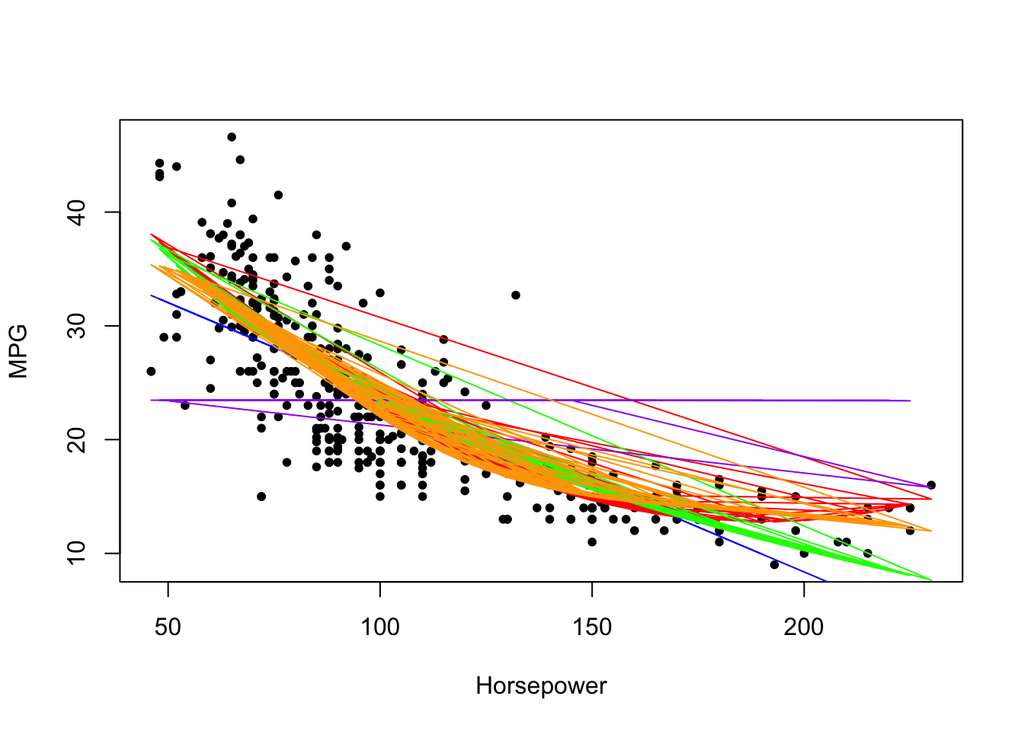

```r
attach(Auto)
data(Auto)

# Fit nonlinear models
lm.fit <- lm(mpg ~ horsepower, data = Auto)
quad.fit <- lm(mpg ~ horsepower + I(horsepower^2), data = Auto)
log.fit <- lm(mpg ~ log(horsepower), data = Auto)
exp.fit <- lm(mpg ~ exp(horsepower), data = Auto)
spline.fit <- lm(mpg ~ bs(horsepower, df = 4), data = Auto)


rse.lm <- sqrt(mean(lm.fit$residuals^2))
rse.quad <- sqrt(mean(quad.fit$residuals^2))
rse.log <- sqrt(mean(log.fit$residuals^2))
rse.exp <- sqrt(mean(exp.fit$residuals^2))
rse.spline <- sqrt(mean(spline.fit$residuals^2))


plot(Auto$horsepower, Auto$mpg, pch = 20, xlab = "Horsepower", ylab = "MPG")
lm_preds <- predict(lm.fit)
lines(Auto$horsepower, lm_preds, col = "blue")
quad_preds <- predict(quad.fit)
lines(Auto$horsepower, quad_preds, col = "red")
log_preds <- predict(log.fit)
lines(Auto$horsepower, log_preds, col = "green")
exp_preds <- predict(exp.fit)
lines(Auto$horsepower, exp_preds, col = "purple")
spline_preds <- predict(spline.fit)
lines(Auto$horsepower, spline_preds, col = "orange")
```

### ISLR Chapter 7 Applied Exercise 9 (14 pts)

### (a)

```r
data(Boston)

attach(Boston)

fit <- lm(nox ~ poly(dis, 3), data = Boston)
summary(fit)
```

```
##
## Call:
## lm(formula = nox ~ poly(dis, 3), data = Boston)
##
## Residuals:
##       Min        1Q    Median        3Q       Max
## -0.121130 -0.040619 -0.009738  0.023385  0.194904
##
## Coefficients:
##                Estimate Std. Error t value Pr(>|t|)
## (Intercept)    0.554695   0.002759 201.021  < 2e-16 ***
## poly(dis, 3)1 -2.003096   0.062071 -32.271  < 2e-16 ***
## poly(dis, 3)2  0.856330   0.062071  13.796  < 2e-16 ***
## poly(dis, 3)3 -0.318049   0.062071  -5.124 4.27e-07 ***
## ---
## Signif. codes:  0 '***' 0.001 '**' 0.01 '*' 0.05 '.' 0.1 ' ' 1
##
## Residual standard error: 0.06207 on 502 degrees of freedom
## Multiple R-squared:  0.7148, Adjusted R-squared:  0.7131
## F-statistic: 419.3 on 3 and 502 DF,  p-value: < 2.2e-16
```

### (b)

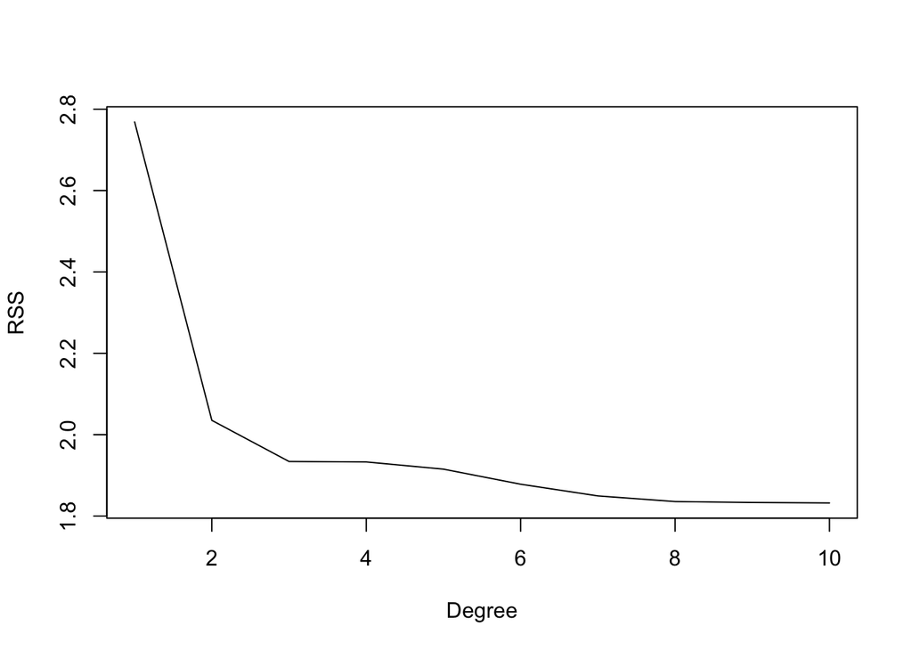

```r
r <- rep(NA, 10)
  rss <- rep(NA, length(r))

for (i in 1:10) {
  fit <- lm(nox ~ poly(dis, i), data = Boston)
  rss[i] <- sum(fit$residuals ^ 2)

}
plot(1:10, rss, type = 'l', xlab = "Degree", ylab = "RSS")
```

### (c)

Optimal value looks to be at 3.

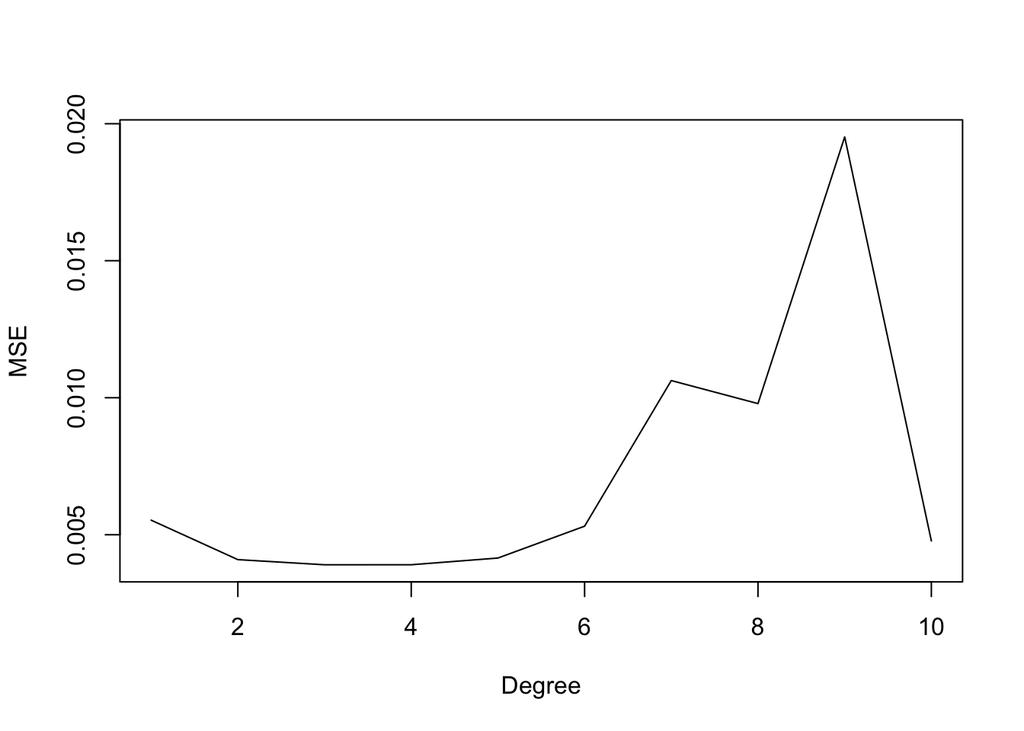

```r
t <- rep(NA, 10)
rss <- rep(NA, length(t))

for (i in 1:10) {
  fit <- glm(nox ~ poly(dis, i), data = Boston)
  rss[i] <- cv.glm(Boston, fit, K = 20)$delta[1]
}
plot(1:10, rss, type = 'l', xlab = "Degree", ylab = "MSE")
```

### (d)

Chosen by the basis in the regression spline in the graphing above. Also, we see a lot of non-normality as it deviates from the line in plot 2.

```r
fit.bs <- lm(nox ~ bs(dis, df = 4), data = Boston)
summary(fit.bs)
```

```
##
## Call:
## lm(formula = nox ~ bs(dis, df = 4), data = Boston)
##
## Residuals:
##       Min        1Q    Median        3Q       Max
## -0.124622 -0.039259 -0.008514  0.020850  0.193891
##
## Coefficients:
##                  Estimate Std. Error t value Pr(>|t|)
## (Intercept)       0.73447    0.01460  50.306  < 2e-16 ***
## bs(dis, df = 4)1 -0.05810    0.02186  -2.658  0.00812 **
## bs(dis, df = 4)2 -0.46356    0.02366 -19.596  < 2e-16 ***
## bs(dis, df = 4)3 -0.19979    0.04311  -4.634 4.58e-06 ***
## bs(dis, df = 4)4 -0.38881    0.04551  -8.544  < 2e-16 ***
## ---
## Signif. codes:  0 '***' 0.001 '**' 0.01 '*' 0.05 '.' 0.1 ' ' 1
##
## Residual standard error: 0.06195 on 501 degrees of freedom
## Multiple R-squared:  0.7164, Adjusted R-squared:  0.7142
## F-statistic: 316.5 on 4 and 501 DF,  p-value: < 2.2e-16
```

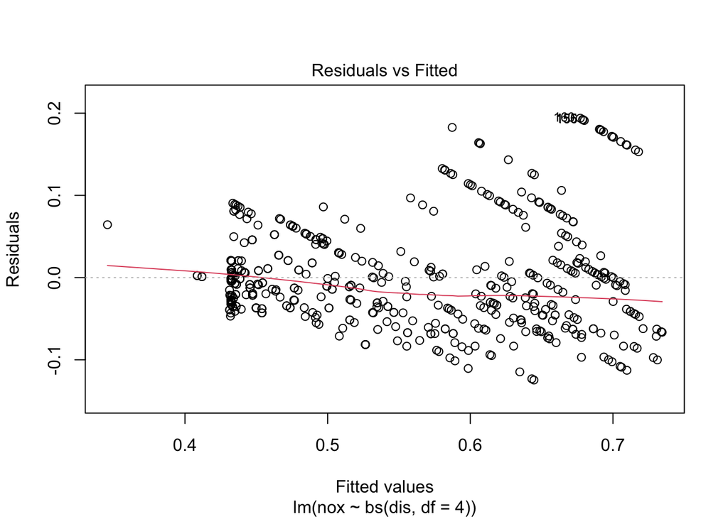

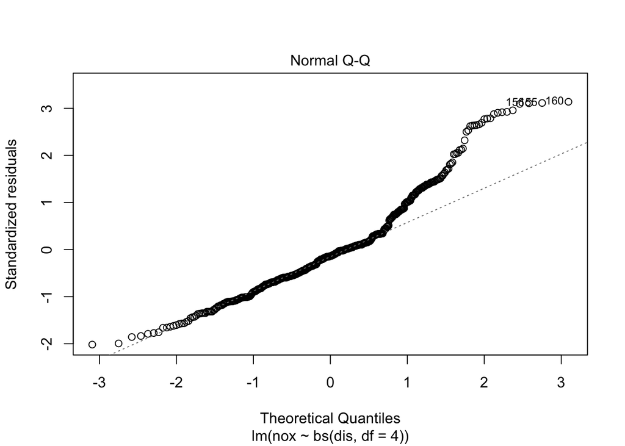

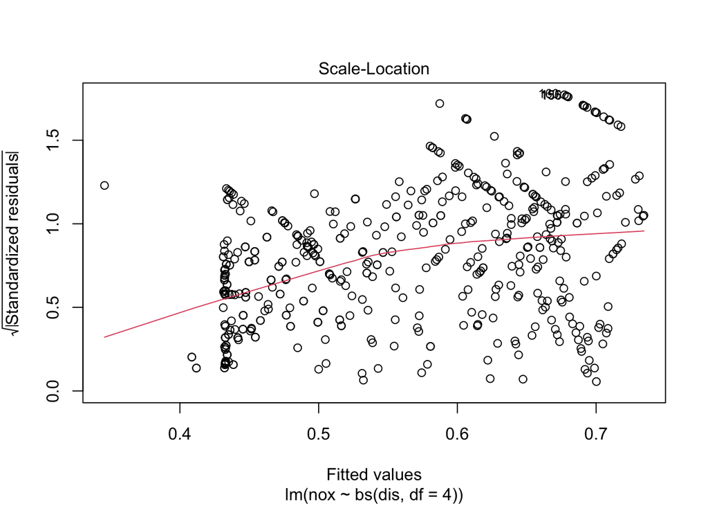

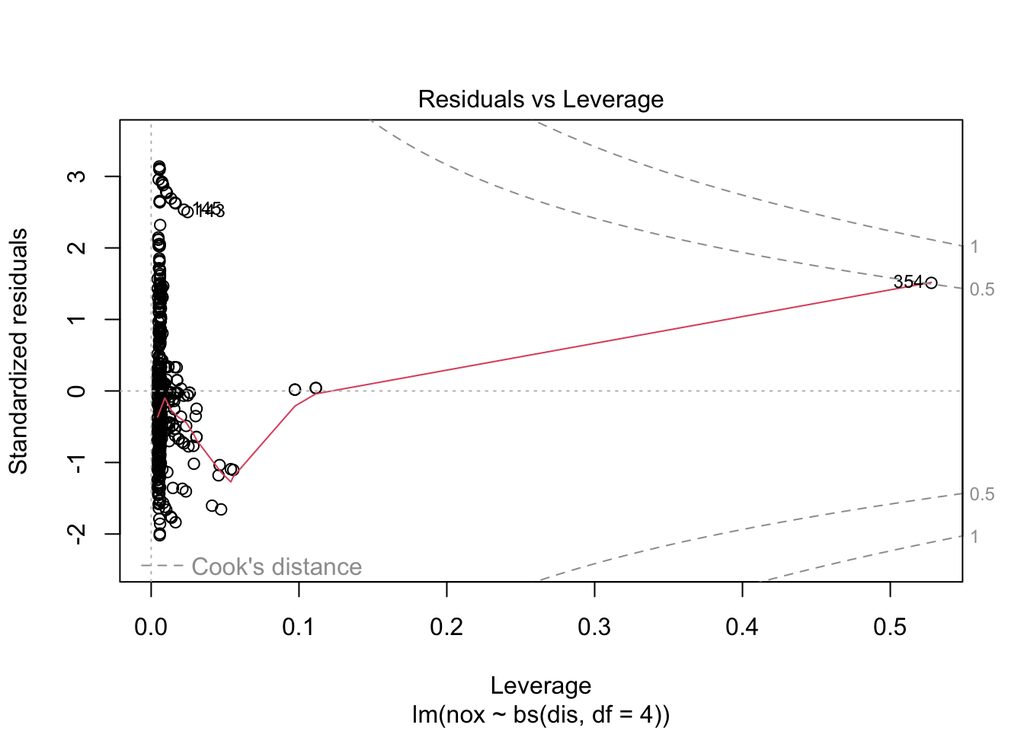

```r
plot(fit.bs)
```

### (e)

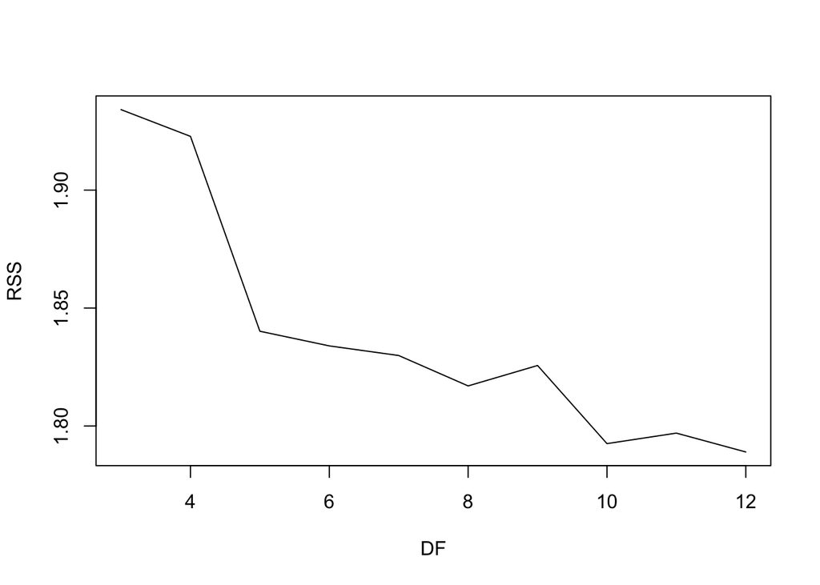

```r
library(splines)

df <- seq(3, 12, by = 1)

rss <- rep(NA, length(df))

for(i in 1:length(df)) {
  fit <- lm(nox ~ bs(dis, df = df[i]), data = Boston)
  rss[i] <- sum(fit$residuals^2)
}

plot(df, rss, type = "l", xlab = "DF", ylab = "RSS")
```

There seems to be a lot of knots and downfall in the graph. The optimal value is at 12 it seems.

### (f)

```r
t <- rep(NA, 12)
for (i in 3:12) {
  fit <- glm(nox ~ bs(dis, i), data = Boston)
  t[i] <- cv.glm(Boston, fit, K = 10)$delta[1]

}
```

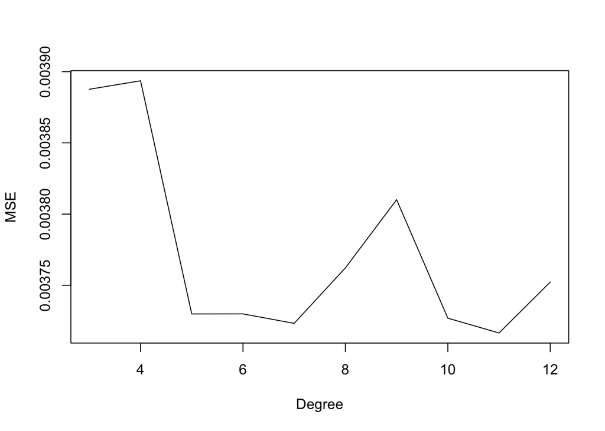

```r
plot(3:12, t[-c(1,2)], type = 'l', xlab = "Degree", ylab = "MSE")
```

### ISLR Chapter 7 Applied Exercise 10 (10 pts)

### (a)

```r
set.seed(1)
data(College)

train <- sample(nrow(College), nrow(College) * 0.7)

training <- College[train,]
testing <- College[-train,]


fit <- regsubsets(Outstate ~ ., data = training, nvmax = 17, method = "forward")
fit.summary <- summary(fit)
```

### (b)

We can see that there is an increasing slope in a few models like Room.Board, but at a slower rate. This means that the the increasing amount has higher tendency to cost. On the other hand, we see the model Expend increases at a dramatic rate compared to the rest meaning the Expend must have sky rocketed at a dramatic rate. Also, we can see that there are more in private to yes for the cost.

```r
gam.fit <- gam(Outstate ~ Private + s(Room.Board) + s(PhD) + s(perc.alumni) + s(Expend) + s(Grad.Rate), data = training)
summary(gam.fit)
```

```
##
## Call: gam(formula = Outstate ~ Private + s(Room.Board) + s(PhD) + s(perc.alumni) +
##     s(Expend) + s(Grad.Rate), data = training)
## Deviance Residuals:
##      Min       1Q   Median       3Q      Max
## -7519.76 -1172.56    43.88  1258.04  7823.01
##
## (Dispersion Parameter for gaussian family taken to be 3605337)
##
##     Null Deviance: 9260683704 on 542 degrees of freedom
## Residual Deviance: 1878379197 on 520.9996 degrees of freedom
## AIC: 9762.683
##
## Number of Local Scoring Iterations: NA
##
## Anova for Parametric Effects
##                 Df     Sum Sq    Mean Sq F value    Pr(>F)
## Private          1 2402704131 2402704131 666.430 < 2.2e-16 ***
## s(Room.Board)    1 1721876417 1721876417 477.591 < 2.2e-16 ***
## s(PhD)           1  617453951  617453951 171.261 < 2.2e-16 ***
## s(perc.alumni)   1  458198124  458198124 127.089 < 2.2e-16 ***
## s(Expend)        1  748043911  748043911 207.482 < 2.2e-16 ***
## s(Grad.Rate)     1   99638346   99638346  27.636  2.14e-07 ***
## Residuals      521 1878379197    3605337
## ---
## Signif. codes:  0 '***' 0.001 '**' 0.01 '*' 0.05 '.' 0.1 ' ' 1
##
## Anova for Nonparametric Effects
##                Npar Df Npar F   Pr(F)
## (Intercept)
## Private
## s(Room.Board)        3  2.727 0.04349 *
## s(PhD)               3  1.141 0.33188
## s(perc.alumni)       3  0.987 0.39863
## s(Expend)            3 32.789 < 2e-16 ***
## s(Grad.Rate)         3  2.064 0.10401
## ---
## Signif. codes:  0 '***' 0.001 '**' 0.01 '*' 0.05 '.' 0.1 ' ' 1
```

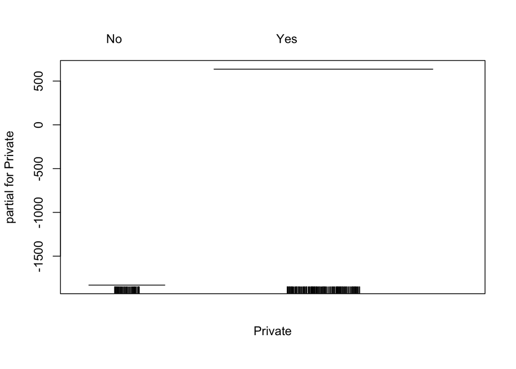

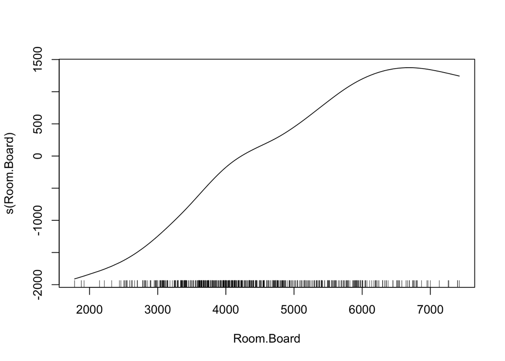

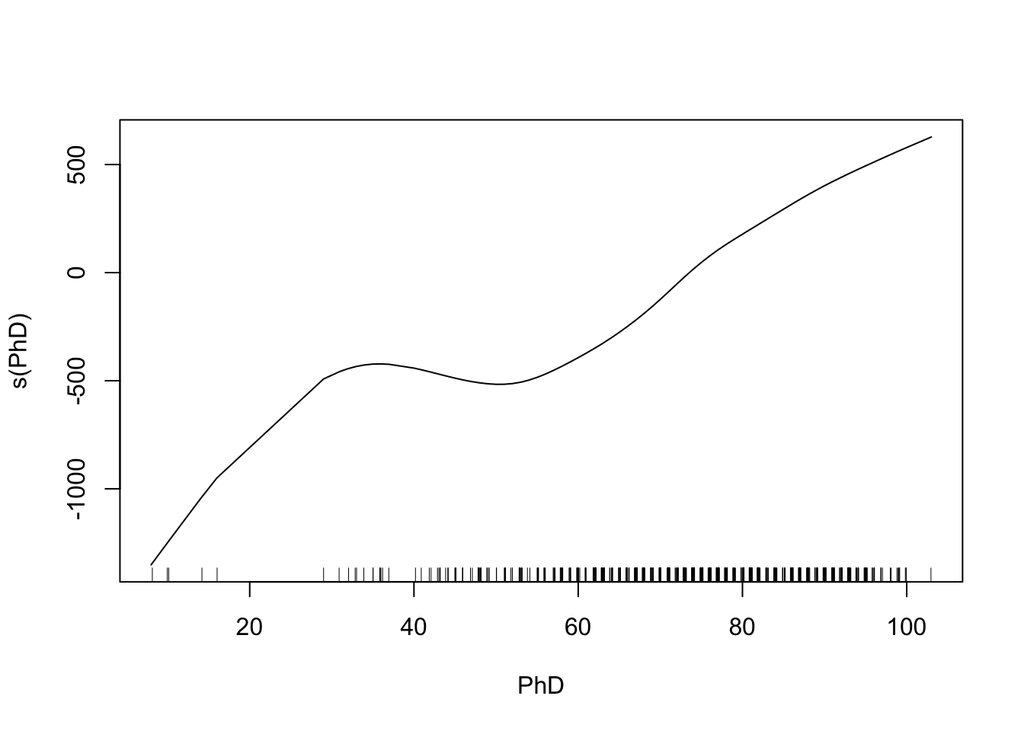

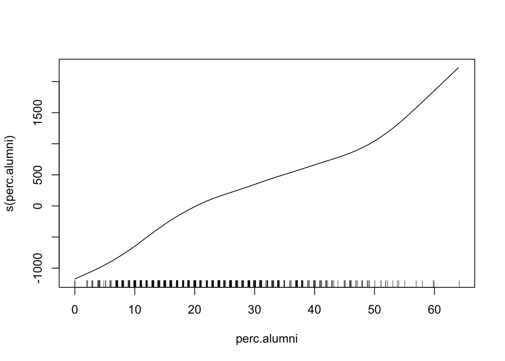

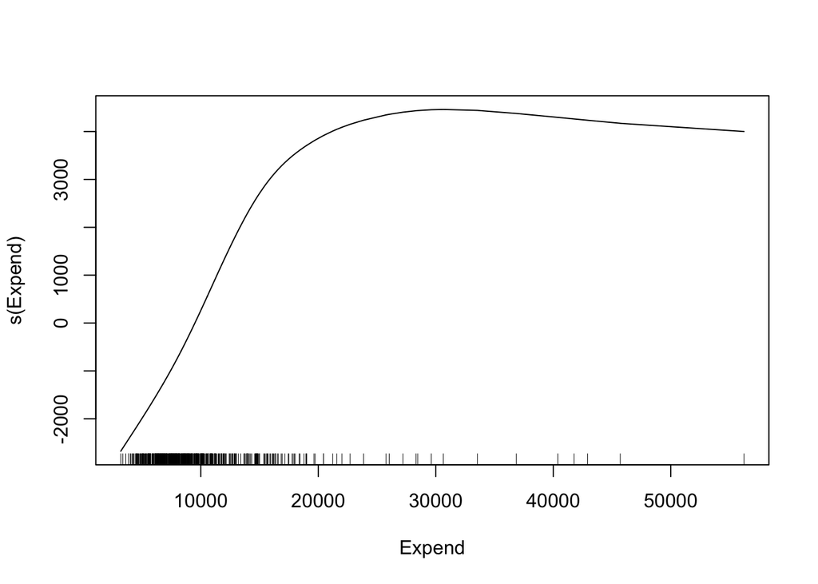

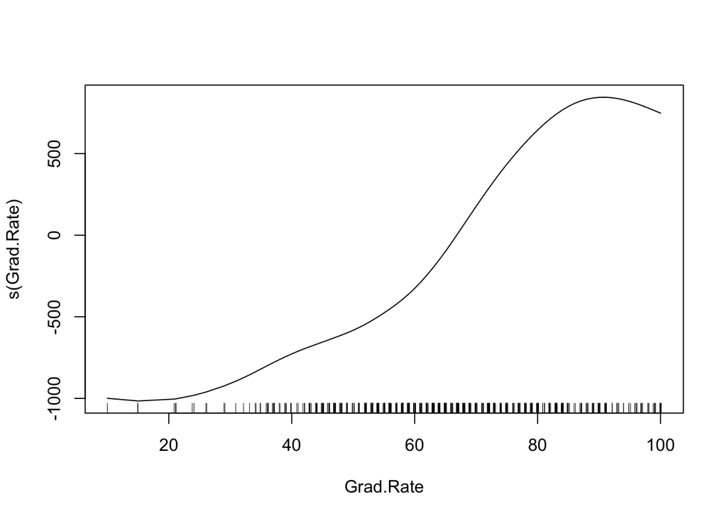

```r
plot(gam.fit, pages = 1, all.terms = TRUE)
```

### (c)

R^2 is 0.77, meaning 77% of the variability can be explained by the differences in the data. It is moderate to strong correlation.

```r
pred <- predict(gam.fit, newdata = testing)
res <- sum((testing$Outstate - pred)^2)
tot <- sum((testing$Outstate - mean(training$Outstate))^2)
rsq <- 1 - (res / tot)
rsq
```

```
## [1] 0.7749034
```

### (d)

```r
summary(gam.fit)
```

```
##
## Call: gam(formula = Outstate ~ Private + s(Room.Board) + s(PhD) + s(perc.alumni) +
##     s(Expend) + s(Grad.Rate), data = training)
## Deviance Residuals:
##      Min       1Q   Median       3Q      Max
## -7519.76 -1172.56    43.88  1258.04  7823.01
##
## (Dispersion Parameter for gaussian family taken to be 3605337)
##
##     Null Deviance: 9260683704 on 542 degrees of freedom
## Residual Deviance: 1878379197 on 520.9996 degrees of freedom
## AIC: 9762.683
##
## Number of Local Scoring Iterations: NA
##
## Anova for Parametric Effects
##                 Df     Sum Sq    Mean Sq F value    Pr(>F)
## Private          1 2402704131 2402704131 666.430 < 2.2e-16 ***
## s(Room.Board)    1 1721876417 1721876417 477.591 < 2.2e-16 ***
## s(PhD)           1  617453951  617453951 171.261 < 2.2e-16 ***
## s(perc.alumni)   1  458198124  458198124 127.089 < 2.2e-16 ***
## s(Expend)        1  748043911  748043911 207.482 < 2.2e-16 ***
## s(Grad.Rate)     1   99638346   99638346  27.636  2.14e-07 ***
## Residuals      521 1878379197    3605337
## ---
## Signif. codes:  0 '***' 0.001 '**' 0.01 '*' 0.05 '.' 0.1 ' ' 1
##
## Anova for Nonparametric Effects
##                Npar Df Npar F   Pr(F)
## (Intercept)
## Private
## s(Room.Board)        3  2.727 0.04349 *
## s(PhD)               3  1.141 0.33188
## s(perc.alumni)       3  0.987 0.39863
## s(Expend)            3 32.789 < 2e-16 ***
## s(Grad.Rate)         3  2.064 0.10401
## ---
## Signif. codes:  0 '***' 0.001 '**' 0.01 '*' 0.05 '.' 0.1 ' ' 1
```